# Selina Narain DTSC 630 Homework 3

2023-03-25

## Question 1

**Import the pupae data, then**

```r
# Initialize and read data
pupae <- read.csv("pupae.csv")

head(pupae)
```

```
##   T_treatment CO2_treatment Gender PupalWeight Frass
## 1     ambient           280      0       0.244 1.900
## 2     ambient           280      1       0.319 2.770
## 3     ambient           280      0       0.221    NA
## 4     ambient           280      0       0.280 1.996
## 5     ambient           280      0       0.257 1.069
## 6     ambient           280      1       0.333 2.257
```

```r
summary(pupae)
```

```
##  T_treatment        CO2_treatment       Gender        PupalWeight
##  Length:84          Min.   :280.0   Min.   :0.0000   Min.   :0.1720
##  Class :character   1st Qu.:280.0   1st Qu.:0.0000   1st Qu.:0.2562
##  Mode  :character   Median :400.0   Median :0.0000   Median :0.2975
##                     Mean   :344.3   Mean   :0.4487   Mean   :0.3110
##                     3rd Qu.:400.0   3rd Qu.:1.0000   3rd Qu.:0.3560
##                     Max.   :400.0   Max.   :1.0000   Max.   :0.4730
##                                     NA's   :6
##      Frass
##  Min.   :0.986
##  1st Qu.:1.515
##  Median :1.818
##  Mean   :1.846
##  3rd Qu.:2.095
##  Max.   :3.117
##  NA's   :1
```

- Convert the variable ”CO2 treatment” to a factor. Inspect the levels of this factor variable.

```r
# Make a factor variable of CO2 treatment
pupae$CO2_treatment <- factor(pupae$CO2_treatment,
                              levels=c(280, 400),
                              labels=c("280ppm", "400ppm"))
```

- Make a scatter plot of Frass vs. PupalWeight, with blue solid circles for a CO2 concentration of 280ppm and red for 400ppm. Also add a legend.

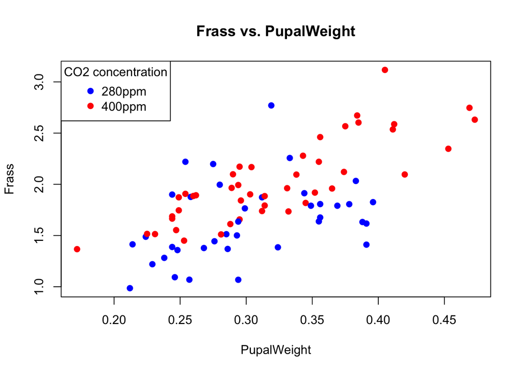

```r
# Create palette to store colors to be used in a plot
palette(c("blue", "red"))

# y ~ x : y for y axis and x for x axis
# Frass ~ PupalWeight : Frass for y axis and PupalWeight for x axis
plot(Frass ~ PupalWeight,
     main = "Frass vs. PupalWeight",
     data = pupae,
     col = CO2_treatment,
     pch = 19)

# Add a legend
legend("topleft",
       title = "CO2 concentration",
       levels(pupae$CO2_treatment),
       col = palette(),
       pch = 19)
```

- Make side-by-side plots (similar to the above figure), one with the ’ambient’ temperature treatment, one with ’elevated’. In order to better compare data among the two treatment groups (that is the reason for drawing the side-by-side plot), make sure that the X and Y axis ranges are the same for both plots (Hint: use xlim and ylim)

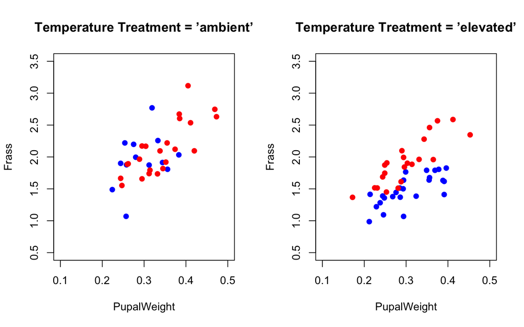

```r
#Setting the plot area to a 1 by 2 array. One row of plots, and two columns.
par(mfrow = c(1, 2))

#Takes subset of ambient data and load into dataframe
ambient_df <- subset(pupae, T_treatment =="ambient")

#Takes subset of elevated data and load into dataframe
elevated_df <- subset(pupae, T_treatment =="elevated")

#Left graph
plot(Frass ~ PupalWeight,
     main = "Temperature Treatment = ’ambient’",
     data = ambient_df,
     col = CO2_treatment,
     pch = 19,
     xlim = c(0.1, 0.5),
     ylim = c(0.5, 3.5))

#Right graph
plot(Frass ~ PupalWeight,
     main = "Temperature Treatment = ’elevated’",
     data = elevated_df,
     col = CO2_treatment,
     pch = 19,
     xlim = c(0.1, 0.5),
     ylim = c(0.5, 3.5))
```

## Question 2

**Sometimes we want to combine the side-by-side plots into a single plot with combinations of symbols and colors to distinguish subgroups. Here you will generate the plot as below. Note that you can either use just plot() function with col and pch option specified for appropriate subgroups without points() functions, or use the approach we have learned (plot + points)**

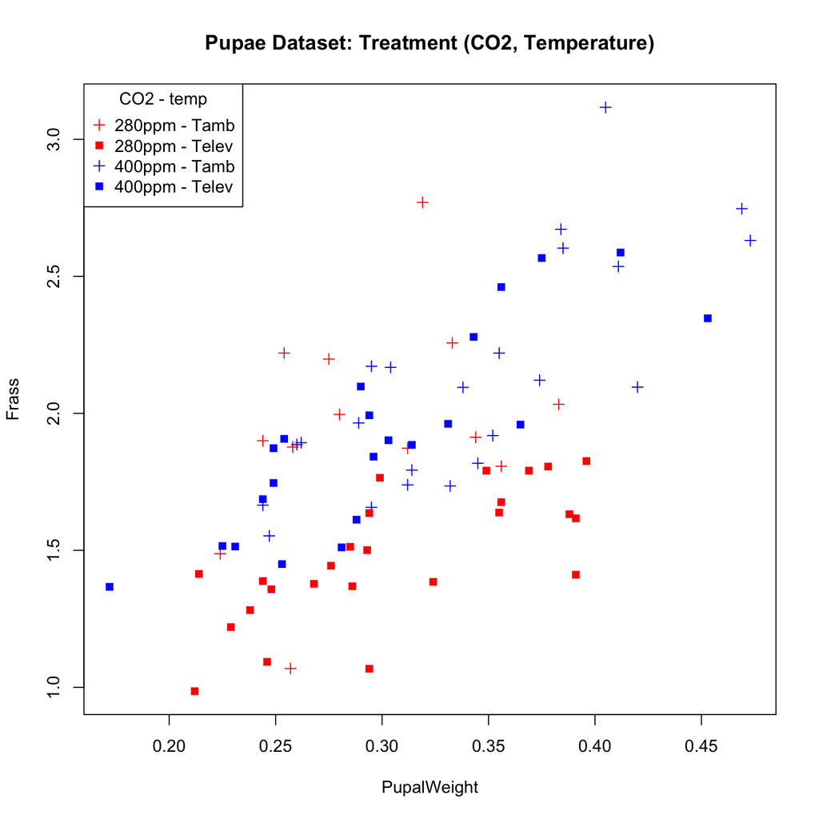

```r
# Create palette to store colors to be used in a plot
palette(c("red", "blue"))

# Combine plots for temperature treatment (’ambient’ and ’elevated’) and CO2 concentration (280ppm and 400ppm)
plot(Frass ~ PupalWeight,
     main = "Pupae Dataset: Treatment (CO2, Temperature)",
     data = pupae,
     col = CO2_treatment,
     pch = c(3, 15)[as.factor(T_treatment)])

# Add a legend
legend("topleft",
       title = "CO2 - temp",
       c("280ppm - Tamb", "280ppm - Telev", "400ppm - Tamb", "400ppm - Telev"),
       col = c(palette()[1], palette()[1], palette()[2],palette()[2]),
       pch = c(3, 15, 3, 15))
```